#### Dragos Ailoae

2021-09-19

# Introduction to R

### Data Structures, Packages, Plots, Read/Write Files

### Data structures

**Vectors**: The most common and basic data structure in R and is pretty much the workhorse of R:

```r
x <- c(2, 4, 6)
x
class(x)
```

1. 2

2. 4

3. 6

'numeric'

In R **matrices** are an extension of the numeric or character vectors. The elements of a matrix must be of the same data type.

```r
m <- matrix(data = c(2,3,-2,1,2,2),nrow = 3,ncol = 2)
m
class(m)
```

A matrix: 3 × 2 of type dbl

| 2 | 1 |
| --- | --- |
| 3 | 2 |
| -2 | 2 |

'matrix'

A **list** is a collection of elements which can be of different types.

```r
l <- list(x = 1:5, y = c('a', 'b'))
str(l)
```

```
List of 2
 $ x: int [1:5] 1 2 3 4 5
 $ y: chr [1:2] "a" "b"
```

A **data frame** is a special case of a list where all elements are the same length.

```r
df <- data.frame(x = 1:3, y = 20:22)
df
```

A data.frame: 3 × 2

| x <int> | y <int> |
| --- | --- |
| 1 | 20 |
| 2 | 21 |
| 3 | 22 |

```r
str(df)
class(df)
typeof(df)
```

```
'data.frame':	3 obs. of  2 variables:
 $ x: int  1 2 3
 $ y: int  20 21 22
```

'data.frame'

'list'

**Time series** are vectors or matrices with class of "ts" (and additional attributes) and represent data which has been sampled at equispaced points in time.

```r
myts <- ts(df, start=c(2009, 1), end=c(2009, 3), frequency=12)
myts
```

A Time Series: 3 × 2

|  | x | y |
| --- | --- | --- |
| Jan 2009 | 1 | 20 |
| Feb 2009 | 2 | 21 |
| Mar 2009 | 3 | 22 |

### To work with data from packages:

Packages can be installed using the RStudio GUI (Tools->Install Packages) or with the following command:

```r
# install.packages('AER')
```

To use the package:

```r
# library(AER)
```

Or, combine the two: ask R to use the package and, if package not yet installed, go ahead and install it:

```r
# if(!require(AER)){install.packages('AER')}
```

To load and install packages silently without all the library load messages:

```r
options(warn=-1) # Suppress warnings
qui <- suppressPackageStartupMessages # quiet! - suppress library load messages

# install (if not already installed) and load package
qui(if(!require(AER)){install.packages('AER')})       # for 'USConsump1979' dataset

data(USConsump1979)                                   # Load dataset
mydata <− USConsump1979                               # Assign to a variable

mydata
```

A Time Series: 10 × 2

|  | income | expenditure |
| --- | --- | --- |
| 1970 | 751.6 | 672.1 |
| 1971 | 779.2 | 696.8 |
| 1972 | 810.3 | 737.1 |
| 1973 | 864.7 | 767.9 |
| 1974 | 857.5 | 762.8 |
| 1975 | 874.9 | 779.4 |
| 1976 | 906.8 | 823.1 |
| 1977 | 942.9 | 864.3 |
| 1978 | 988.8 | 903.2 |
| 1979 | 1015.7 | 927.6 |

We can convert a timeseries object to a data frame:

```r
mydata.df <- data.frame(year=time(mydata),as.matrix(mydata))
mydata.df
```

A data.frame: 10 × 3

| year <ts> | income <dbl> | expenditure <dbl> |
| --- | --- | --- |
| 1970 | 751.6 | 672.1 |
| 1971 | 779.2 | 696.8 |
| 1972 | 810.3 | 737.1 |
| 1973 | 864.7 | 767.9 |
| 1974 | 857.5 | 762.8 |
| 1975 | 874.9 | 779.4 |
| 1976 | 906.8 | 823.1 |
| 1977 | 942.9 | 864.3 |
| 1978 | 988.8 | 903.2 |
| 1979 | 1015.7 | 927.6 |

To see data structure:

```r
str(mydata.df)
```

```
'data.frame':	10 obs. of  3 variables:
 $ year       : Time-Series  from 1970 to 1979: 1970 1971 1972 1973 1974 ...
 $ income     : num  752 779 810 865 858 ...
 $ expenditure: num  672 697 737 768 763 ...
```

Syntax for addressing columns in a timeseries object is different from a dataframe:

```r
print(mydata[,'income'])
```

```
Time Series:
Start = 1970
End = 1979
Frequency = 1
 [1]  751.6  779.2  810.3  864.7  857.5  874.9  906.8  942.9  988.8 1015.7
```

```r
print(mydata.df$income)
```

```
 [1]  751.6  779.2  810.3  864.7  857.5  874.9  906.8  942.9  988.8 1015.7
```

**NOTE:** While we can convert a timeseries object to a data frame, timeseries data generally has some special attributes. Many analytical functions in R require timeseries objects as input so it's good to get used to working with these type of objects directly.

Let's add a third column named $savings\equiv (income - expenditures)$:

```r
savings <- mydata[,'income'] - mydata[,'expenditure']
print(savings)
```

```
Time Series:
Start = 1970
End = 1979
Frequency = 1
 [1] 79.5 82.4 73.2 96.8 94.7 95.5 83.7 78.6 85.6 88.1
```

```r
mydata <- ts.union(income = mydata[,'income'], expenditure=mydata[,'expenditure'],savings)
mydata
```

A Time Series: 10 × 3

|  | income | expenditure | savings |
| --- | --- | --- | --- |
| 1970 | 751.6 | 672.1 | 79.5 |
| 1971 | 779.2 | 696.8 | 82.4 |
| 1972 | 810.3 | 737.1 | 73.2 |
| 1973 | 864.7 | 767.9 | 96.8 |
| 1974 | 857.5 | 762.8 | 94.7 |
| 1975 | 874.9 | 779.4 | 95.5 |
| 1976 | 906.8 | 823.1 | 83.7 |
| 1977 | 942.9 | 864.3 | 78.6 |
| 1978 | 988.8 | 903.2 | 85.6 |
| 1979 | 1015.7 | 927.6 | 88.1 |

Single line plot:

[figure not shown]

```r
plot(mydata[,'income'],main="U.S. Savings", xlab="Year",ylab="Bn USD",col = "blue", lwd = 4)
```

To plot multiple lines on the same chart:

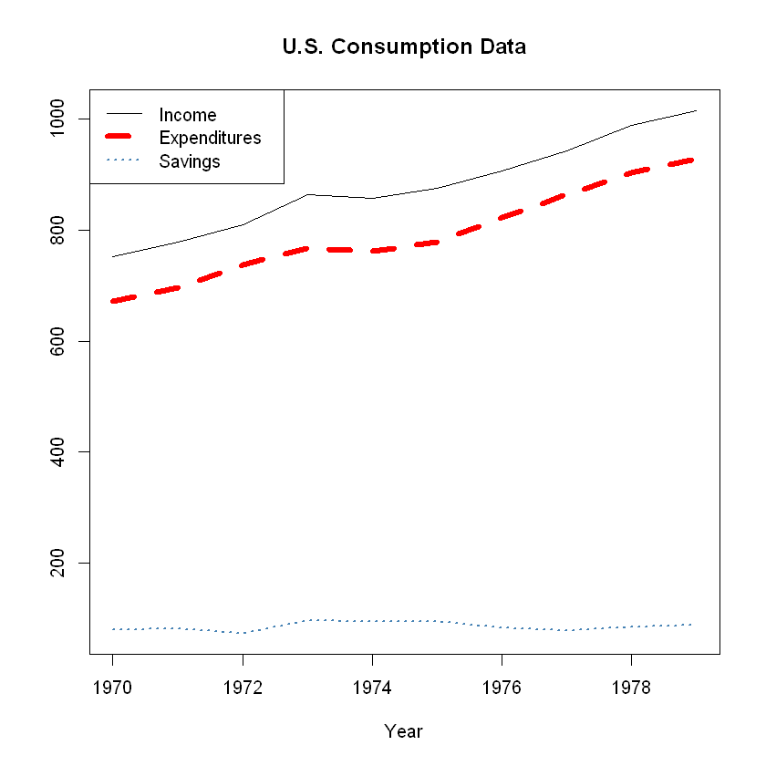

```r
plot(mydata,
    plot.type = "single",
    col = c("black", "red", "steelblue"),
    lwd = c(1, 5, 2),
    lty = c(1, 2, 3),
    xlab = "Year",
    ylab = "",
    main = "U.S. Consumption Data")
    legend("topleft",
    legend = c("Income", "Expenditures","Savings"),
    col = c("black", "red", "steelblue"),
    lwd = c(1, 5, 2),
    lty = c(1, 2, 3)
    )
```

To create a plot grid:

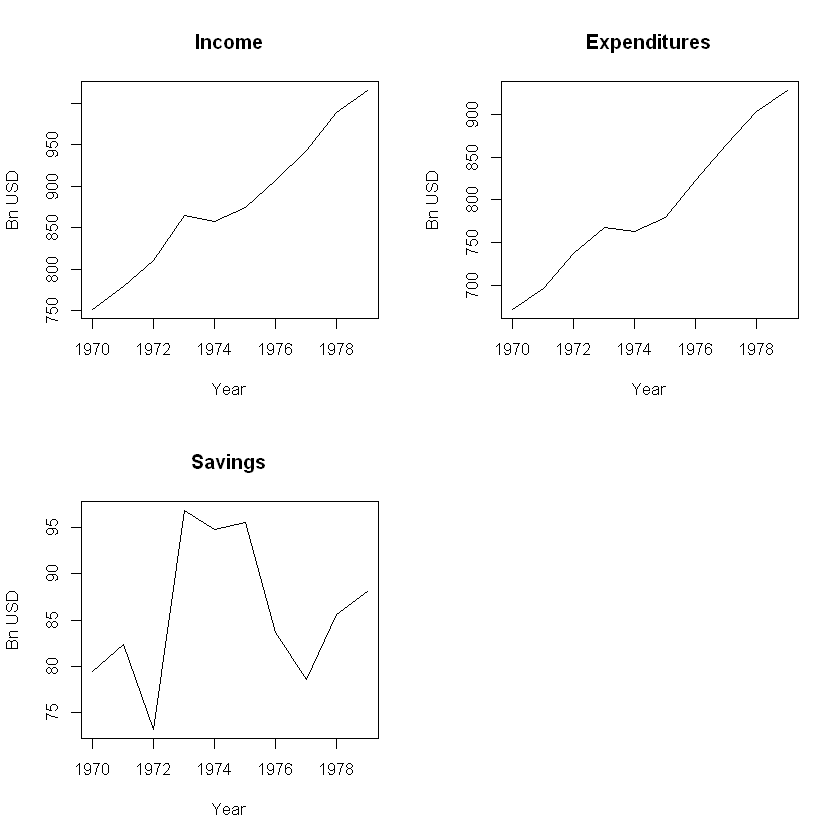

```r
par(mfrow=c(2,2))
plot(mydata[,'income'],xlab="Year",ylab="Bn USD",
main="Income",cex=0.7)
plot(mydata[,'expenditure'],xlab="Year",ylab="Bn USD",
main="Expenditures",cex=0.7)
plot(mydata[,'savings'],xlab="Year",ylab="Bn USD",
main="Savings",cex=0.7)
```

To export original dataset to a CSV file:

```r
write.csv(mydata.df,'my_file.csv')
# getwd()        #to find working directory
```

To import data from a file:

```r
my.df <- read.csv('my_file.csv')
my.df
```

A data.frame: 10 × 4

| X <int> | year <int> | income <dbl> | expenditure <dbl> |
| --- | --- | --- | --- |
| 1 | 1970 | 751.6 | 672.1 |
| 2 | 1971 | 779.2 | 696.8 |
| 3 | 1972 | 810.3 | 737.1 |
| 4 | 1973 | 864.7 | 767.9 |
| 5 | 1974 | 857.5 | 762.8 |
| 6 | 1975 | 874.9 | 779.4 |
| 7 | 1976 | 906.8 | 823.1 |
| 8 | 1977 | 942.9 | 864.3 |
| 9 | 1978 | 988.8 | 903.2 |
| 10 | 1979 | 1015.7 | 927.6 |

Convert the dataset we just loaded from the file to a timeseries object:

```r
my.new.ts <- ts(my.df[,3:4],start=c(1970),freq = 1)
my.new.ts
```

A Time Series: 10 × 2

|  | income | expenditure |
| --- | --- | --- |
| 1970 | 751.6 | 672.1 |
| 1971 | 779.2 | 696.8 |
| 1972 | 810.3 | 737.1 |
| 1973 | 864.7 | 767.9 |
| 1974 | 857.5 | 762.8 |
| 1975 | 874.9 | 779.4 |
| 1976 | 906.8 | 823.1 |
| 1977 | 942.9 | 864.3 |
| 1978 | 988.8 | 903.2 |
| 1979 | 1015.7 | 927.6 |